# 1. Introduction

## How Can a Wellness Technology Company Play It Smart?

### Step 1: Ask

#### Background

Bellabeat is a high-tech company that manufactures health-focused smart products. They offer various smart devices that collect data on activity, sleep, stress, and reproductive health to empower women with insights about their well-being and habits.

The main goal of this case study is to analyze smart device fitness data and determine how it could help unlock new growth opportunities for Bellabeat. We will focus specifically on one of Bellabeat’s flagship products: the **Bellabeat App**.

The Bellabeat app provides users with health data related to their activity, sleep, stress, menstrual cycle, and mindfulness habits. This data enables users to better understand their current behaviors and make healthier decisions. The app integrates seamlessly with Bellabeat’s suite of smart wellness devices.

#### Key Stakeholders

- **Urška Sršen** — Bellabeat’s co-founder and Chief Creative Officer
- **Sando Mur** — Bellabeat’s co-founder and Chief Technology Officer
- **Marketing Analytics Team** — responsible for discovering growth opportunities through data

## Step 2: Prepare

### Dataset Used

The dataset used for this case study is **FitBit Fitness Tracker Data**. It is hosted on [Kaggle](https://www.kaggle.com/datasets/arashnic/fitbit) and was made available by **Mobius**. The data was generated by respondents to a distributed survey via **Amazon Mechanical Turk** between **March 12, 2016** and **May 12, 2016**.

### Accessibility and Privacy of Data

The dataset is licensed under **CC0: Public Domain**, meaning the creator has waived all rights to the work worldwide under copyright law. This allows anyone to copy, modify, distribute, or perform the work — even for commercial purposes — without requesting permission.

### Data Organization and Verification

The dataset is a collection of **18 CSV files**, including **15 in long format** and **3 in wide format**. It contains diverse information such as activity metrics, calories burned, sleep records, metabolic equivalent tasks (METs), heart rate, and step counts — recorded across different time intervals (seconds, minutes, hours, and days).

### Data Limitations

While the dataset provides valuable insights, several limitations could affect the accuracy and generalizability of the analysis:

- **Missing demographic information** — the dataset lacks details on users’ age, gender, or lifestyle context.
- **Small sample size** — only a limited number of respondents contributed to the dataset.
- **Short data collection period** — the dataset covers a very brief time window (approximately two months).

## Step 3: Process

**Loading Libraries**

```python
import pandas as pd
import numpy as np
import matplotlib.pyplot as plt
import datetime as dt
import seaborn as sns
from pandas.api.types import CategoricalDtype

plt.style.use("ggplot")
```

First, let's import the dataset 'dailyActivity_merged.csv' using the pandas pd.read_csv() function

```python
df=pd.read_csv("dailyActivity_merged.csv")
```

### Data Exploration

Once uploaded, let's firts see how many columns and rows we have, using the pandas function, .shape

```python
df.shape
```

```
(940, 15)
```

The dataset contains 940 rows and 15 columns.

```python
df.columns
```

```
Index(['Id', 'ActivityDate', 'TotalSteps', 'TotalDistance', 'TrackerDistance',
       'LoggedActivitiesDistance', 'VeryActiveDistance',
       'ModeratelyActiveDistance', 'LightActiveDistance',
       'SedentaryActiveDistance', 'VeryActiveMinutes', 'FairlyActiveMinutes',
       'LightlyActiveMinutes', 'SedentaryMinutes', 'Calories'],
      dtype='object')
```

Knowing the names of the columns, let´s take a quick overview at the rows and the data itself, using the .head() pandas function

```python
df.head(10)
```

|  | Id | ActivityDate | TotalSteps | TotalDistance | TrackerDistance | LoggedActivitiesDistance | VeryActiveDistance | ModeratelyActiveDistance | LightActiveDistance | SedentaryActiveDistance | VeryActiveMinutes | FairlyActiveMinutes | LightlyActiveMinutes | SedentaryMinutes | Calories |
| --- | --- | --- | --- | --- | --- | --- | --- | --- | --- | --- | --- | --- | --- | --- | --- |
| 0 | 1503960366 | 4/12/2016 | 13162 | 8.50 | 8.50 | 0.0 | 1.88 | 0.55 | 6.06 | 0.0 | 25 | 13 | 328 | 728 | 1985 |
| 1 | 1503960366 | 4/13/2016 | 10735 | 6.97 | 6.97 | 0.0 | 1.57 | 0.69 | 4.71 | 0.0 | 21 | 19 | 217 | 776 | 1797 |
| 2 | 1503960366 | 4/14/2016 | 10460 | 6.74 | 6.74 | 0.0 | 2.44 | 0.40 | 3.91 | 0.0 | 30 | 11 | 181 | 1218 | 1776 |
| 3 | 1503960366 | 4/15/2016 | 9762 | 6.28 | 6.28 | 0.0 | 2.14 | 1.26 | 2.83 | 0.0 | 29 | 34 | 209 | 726 | 1745 |
| 4 | 1503960366 | 4/16/2016 | 12669 | 8.16 | 8.16 | 0.0 | 2.71 | 0.41 | 5.04 | 0.0 | 36 | 10 | 221 | 773 | 1863 |
| 5 | 1503960366 | 4/17/2016 | 9705 | 6.48 | 6.48 | 0.0 | 3.19 | 0.78 | 2.51 | 0.0 | 38 | 20 | 164 | 539 | 1728 |
| 6 | 1503960366 | 4/18/2016 | 13019 | 8.59 | 8.59 | 0.0 | 3.25 | 0.64 | 4.71 | 0.0 | 42 | 16 | 233 | 1149 | 1921 |
| 7 | 1503960366 | 4/19/2016 | 15506 | 9.88 | 9.88 | 0.0 | 3.53 | 1.32 | 5.03 | 0.0 | 50 | 31 | 264 | 775 | 2035 |
| 8 | 1503960366 | 4/20/2016 | 10544 | 6.68 | 6.68 | 0.0 | 1.96 | 0.48 | 4.24 | 0.0 | 28 | 12 | 205 | 818 | 1786 |
| 9 | 1503960366 | 4/21/2016 | 9819 | 6.34 | 6.34 | 0.0 | 1.34 | 0.35 | 4.65 | 0.0 | 19 | 8 | 211 | 838 | 1775 |

The dataset stores and tracks data collected on a daily basis by FitBit fitness tracking devices, such as smartwatches and fitness apps.  
From a quick look, we can summarize the columns as follows:

- **Id**: A unique identifier for each user in the survey
- **ActivityDate**: The specific date of the entry
- **TotalSteps**: Total number of steps each user took in a day
- **TotalDistance**: Total distance covered by each user in a day
- **TrackerDistance**: Distance tracked by the device each day
- **LoggedActivitiesDistance**: Distance tracked by the device for specific logged activities
- **VeryActiveDistance**: Distance traveled during very active physical activity
- **ModeratelyActiveDistance**: Distance traveled during moderate physical activity
- **LightActiveDistance**: Distance traveled during light physical activity
- **SedentaryActiveDistance**: Distance traveled during sedentary activity
- **VeryActiveMinutes**: Minutes spent being very active
- **FairlyActiveMinutes**: Minutes spent being fairly active
- **LightlyActiveMinutes**: Minutes spent being lightly active
- **SedentaryMinutes**: Minutes spent being sedentary
- **Calories**: Total calories burned that day

Once we’ve reviewed the columns and the data, we can begin the **data cleaning process**.

### Cleaning the Data

#### Checking Data Types

First, we need to check whether the data types align with the content and purpose of each column.  
We can use the `.dtypes` function in pandas to verify this.

```python
df.dtypes
##id should be saved as string othervise the calculations will be performed.
##Date shoud be date formate not object
```

```
Id                            int64
ActivityDate                 object
TotalSteps                    int64
TotalDistance               float64
TrackerDistance             float64
LoggedActivitiesDistance    float64
VeryActiveDistance          float64
ModeratelyActiveDistance    float64
LightActiveDistance         float64
SedentaryActiveDistance     float64
VeryActiveMinutes             int64
FairlyActiveMinutes           int64
LightlyActiveMinutes          int64
SedentaryMinutes              int64
Calories                      int64
dtype: object
```

We can see that the **Id** column is stored as an integer, but it should actually be a **string (object)**.  
This is because the Id serves only as an identifier — it doesn’t represent a numeric value we’d perform mathematical operations on, such as addition or multiplication.

Similarly, the **ActivityDate** column is currently an object, but it should be converted to a **datetime** type so that we can perform date-based operations and analysis.

Other than these two adjustments, all the remaining columns appear to have the correct data types.

```python
df['Id'] = df['Id'].astype(str)
df['ActivityDate'] = pd.to_datetime(df['ActivityDate'],format="%m/%d/%Y")
df.dtypes # After reformating. We double check the data type
```

```
Id                                  object
ActivityDate                datetime64[ns]
TotalSteps                           int64
TotalDistance                      float64
TrackerDistance                    float64
LoggedActivitiesDistance           float64
VeryActiveDistance                 float64
ModeratelyActiveDistance           float64
LightActiveDistance                float64
SedentaryActiveDistance            float64
VeryActiveMinutes                    int64
FairlyActiveMinutes                  int64
LightlyActiveMinutes                 int64
SedentaryMinutes                     int64
Calories                             int64
dtype: object
```

Now we check the formats from before and we will convert the Id column from int to str using the .astype(str) function, and the 'ActivityDate' column from object or string, to datetime

### Checking Column Values

After checking the data types, we can remove columns that are not relevant to our analysis.  
First, let's look at the **TotalDistance** column and the other distance-related columns.

At first glance, **TotalDistance** and **TrackerDistance** appear to have very similar values — but we’re not completely sure yet.  
It’s also possible that **TrackerDistance** or **TotalDistance** represents the sum of the different *ActiveDistance* columns.  
Before making any assumptions, we’ll verify this relationship through further checks.

```python
# We create a new column, adding up the "ActiveDistance" columns to see if it's equal to the 'TotalDistance' column, or the 'TrackerDistance' column
df['sum_distance'] = df['VeryActiveDistance'] + df['ModeratelyActiveDistance'] + df['LightActiveDistance'] + df['SedentaryActiveDistance']

# We also notice that 'LoggedActivitiesDistance' have 0.0 in value in most entries, but we filter to find where has more than 0
df.loc[(df['LoggedActivitiesDistance'] > 0),['TotalDistance','TrackerDistance','LoggedActivitiesDistance','sum_distance']]
```

|  | TotalDistance | TrackerDistance | LoggedActivitiesDistance | sum_distance |
| --- | --- | --- | --- | --- |
| 668 | 5.27 | 5.27 | 1.959596 | 5.08 |
| 689 | 9.71 | 7.88 | 4.081692 | 9.71 |
| 693 | 9.27 | 9.08 | 2.785175 | 9.26 |
| 707 | 8.72 | 8.68 | 3.167822 | 8.73 |
| 711 | 10.29 | 9.48 | 4.869783 | 10.29 |
| 712 | 9.65 | 8.60 | 4.851307 | 9.65 |
| 713 | 8.24 | 7.48 | 3.285415 | 8.25 |
| 717 | 10.98 | 9.91 | 4.930550 | 10.98 |
| 718 | 10.48 | 9.50 | 4.942142 | 10.48 |
| 719 | 11.31 | 10.41 | 4.924841 | 11.32 |
| 724 | 13.34 | 12.20 | 4.861792 | 13.35 |
| 726 | 10.22 | 9.06 | 4.885605 | 10.22 |
| 728 | 14.30 | 13.42 | 4.911146 | 14.31 |
| 731 | 9.18 | 8.72 | 2.832326 | 9.17 |
| 732 | 10.87 | 9.71 | 4.912368 | 10.86 |
| 734 | 11.10 | 10.04 | 4.878232 | 11.10 |
| 818 | 6.05 | 6.05 | 2.253081 | 6.04 |
| 819 | 9.82 | 9.82 | 2.092147 | 9.82 |
| 820 | 10.56 | 10.56 | 2.253081 | 10.56 |
| 824 | 10.81 | 10.81 | 2.092147 | 10.81 |
| 825 | 10.36 | 10.36 | 2.253081 | 10.36 |
| 826 | 7.44 | 7.44 | 2.092147 | 7.45 |
| 827 | 12.01 | 12.01 | 2.253081 | 12.01 |
| 828 | 9.67 | 9.67 | 2.092147 | 9.68 |
| 831 | 9.84 | 9.84 | 2.092147 | 9.84 |
| 838 | 4.81 | 4.81 | 2.092147 | 4.81 |
| 839 | 6.91 | 6.91 | 2.253081 | 6.90 |
| 841 | 6.79 | 6.79 | 2.253081 | 6.79 |
| 842 | 5.59 | 5.59 | 2.092147 | 5.58 |
| 845 | 6.65 | 6.65 | 2.092147 | 6.65 |
| 846 | 5.22 | 5.22 | 2.253081 | 5.22 |
| 847 | 7.25 | 7.25 | 2.092147 | 7.25 |

So now, we have to decide if we want to keep all the columns, or deleting some, we conclude that the 'TotalDistance' column and the 'TotalDistance' are equal in most cases, (having the TotalDistance higher values). so we decide to keep 'TotalDistance'.

About the 'ActiveDistance' columns, unfortunately we don't have an idea behind the categorization, what is the exact diffence between 'Moderately Active' and 'Very Active', maybe the heartbeat pulse at that moment?, steps per minute?, we don't know from this specific dataset, but we will keep them nonetheless.

The same could be said about the 'ActiveMinutes' columns, so we would just add them up in a new column

```python
### manupilation
```

```python
df['TotalMinutes'] = df['VeryActiveMinutes'] + df['FairlyActiveMinutes'] + df['LightlyActiveMinutes'] + df['SedentaryMinutes']
```

```python
print(df.columns.tolist())
```

[output not shown]

### Renaming Columns

Now, let's rename the columns using the `rename()` function.  
We’ll also convert all column names to lowercase using the `str.lower()` method for consistency and easier referencing.

```python
df.columns = df.columns.str.lower()
df.rename(columns = {'trackerdistance':'tracker_distance','activitydate':'activity_date','totalsteps':'total_steps','totaldistance':'total_distance',
       'loggedactivitiesdistance':'logged_activities_distance', 'veryactivedistance':'very_active_distance',
       'moderatelyactivedistance':'moderately_active_distance', 'lightactivedistance':'light_active_distance',
       'sedentaryactivedistance':'sedentary_active_distance', 'veryactiveminutes':'very_active_minutes',
       'fairlyactiveminutes':'fairly_active_minutes','lightlyactiveminutes':'lightly_active_minutes',
       'sedentaryminutes':'sedentary_minutes'}
         ,inplace=True) # We make the changes permanent by using inplace=True
print('Double check the name of the columns:')
df.columns
```

```
Double check the name of the columns:
```

```
Index(['id', 'activity_date', 'total_steps', 'total_distance',
       'tracker_distance', 'logged_activities_distance',
       'very_active_distance', 'moderately_active_distance',
       'light_active_distance', 'sedentary_active_distance',
       'very_active_minutes', 'fairly_active_minutes',
       'lightly_active_minutes', 'sedentary_minutes', 'calories',
       'sum_distance', 'totalminutes'],
      dtype='object')
```

### Creating Columns

Next, let's add two new columns to our dataset:

- One that shows the **day of the week** (e.g., Monday, Tuesday, etc.) using the `day_name()` function.
- Another that shows the **day number of the week** (where Monday = 0, Sunday = 6) using the `weekday()` function.

```python
day_of_week = df['activity_date'].dt.day_name()
df['day_of_week'] = day_of_week
df['n_day_of_week'] = df['activity_date'].dt.weekday # 0 represents monday, 6 represents sunday
```

### Checking Empty Cells and Null Values

Next, we'll check if the dataset contains any missing or null values.  
We can do this using the `isna().sum()` function, which returns the number of null values in each column.

```python
print('Total number of null values are: ')
print(df.isna().sum())
```

```
Total number of null values are:
id                            0
activity_date                 0
total_steps                   0
total_distance                0
tracker_distance              0
logged_activities_distance    0
very_active_distance          0
moderately_active_distance    0
light_active_distance         0
sedentary_active_distance     0
very_active_minutes           0
fairly_active_minutes         0
lightly_active_minutes        0
sedentary_minutes             0
calories                      0
sum_distance                  0
totalminutes                  0
day_of_week                   0
n_day_of_week                 0
dtype: int64
```

Checking for duplicate entries using the function duplicated().sum()

```python
print('Total number of duplicated values are: ',df.duplicated().sum())
```

```
Total number of duplicated values are:  0
```

There are no null values nor duplicated entries

### Subsetting the Data

Now we can select only the columns that are relevant for our analysis.  
In this case, we’ll keep only the columns that provide useful insights about user activity and remove the rest.

```python
df = df[['id', 'activity_date', 'total_steps', 'total_distance',
       #'tracker_distance', 'logged_activities_distance',
       #'very_active_distance', 'moderately_active_distance',
       #'light_active_distance', 'sedentary_active_distance',
       'very_active_minutes', 'fairly_active_minutes',
       'lightly_active_minutes', 'sedentary_minutes', 'calories',
       #'sum_distance','totalminutes',
       'day_of_week', 'n_day_of_week'
        ]].copy()
```

### Category Creation

Now, let's create custom categories for the users based on their **level of physical activity** and **device usage**.

#### Physical Activity Categories

We'll define physical activity levels using the following criteria:

- **Sedentary**: Less than 6,000 daily steps on average
- **Active**: Between 6,000 and 12,000 daily steps on average
- **Very Active**: More than 12,000 daily steps on average

#### Device Usage Categories

- **Low Use**: Less than 8 hours of use per day
- **Normal Use**: Between 8 and 16 hours of use per day
- **High Use**: More than 16 hours of use per day

```python
print(df.columns.tolist())
```

[output not shown]

```python
# I first group the data by the id
id_grp = df.groupby(['id'])

# Then I look for the average amount of steps, and sort the results in descending order
id_avg_step = id_grp['total_steps'].mean().sort_values(ascending=False)

# After that, I turn the results into a dataframe
id_avg_step = id_avg_step.to_frame()

# I want to create a new column which tells in which category each user fits into, depending on the average amount of steps
conditions = [
    (id_avg_step <=6000),
    (id_avg_step > 6000) & (id_avg_step < 12000),
    (id_avg_step >= 12000)
] # These are the conditions

values = ['sedentary','active','very_active'] # And here are the name of the values

# I create a column with the numpy function, np.select to asign each id a category
id_avg_step['activity_level'] = np.select(conditions,values)

# I store the results in a variable to use it in the next step
id_activity_level = id_avg_step['activity_level']

# I use a list comprehension to create the column in our original dataset.
# With this list comprehension I retrieve the categories where the index match the id column
df['activity_level'] = [id_activity_level[c] for c in df['id']]
```

### Step 4: Analyze

Let's start the analysis by checking how many unique users are present in the dataset.  
We can use the `nunique()` function to find the **number** of unique IDs, and the `unique()` function to **list** them.

```python
print('Number of unique values in id column:',df['id'].nunique())
print()
print('List of id values:',df['id'].unique())
```

```
Number of unique values in id column: 33

List of id values: ['1503960366' '1624580081' '1644430081' '1844505072' '1927972279'
 '2022484408' '2026352035' '2320127002' '2347167796' '2873212765'
 '3372868164' '3977333714' '4020332650' '4057192912' '4319703577'
 '4388161847' '4445114986' '4558609924' '4702921684' '5553957443'
 '5577150313' '6117666160' '6290855005' '6775888955' '6962181067'
 '7007744171' '7086361926' '8053475328' '8253242879' '8378563200'
 '8583815059' '8792009665' '8877689391']
```

and now let's see how much they appear in the dataset with value_counts()

```python
print('How many times each id appear in the dataset?')
print(df['id'].value_counts())
```

```
How many times each id appear in the dataset?
id
1503960366    31
4319703577    31
8583815059    31
8378563200    31
8053475328    31
7086361926    31
6962181067    31
5553957443    31
4702921684    31
4558609924    31
1624580081    31
4388161847    31
4445114986    31
```

[output cut: 21 more lines]

As we can see, there are 33 unique id's or users, and most appear 31 times throughout the dataset, some less than that

Now let's check the date column, what is the minimum date, maximum date, the days between them, and number of unique dates

```python
print('The min date is:',min(df['activity_date']))
print('The max date is:',max(df['activity_date']))
print('The number of unique dates are:',df['activity_date'].nunique())
```

```
The min date is: 2016-04-12 00:00:00
The max date is: 2016-05-12 00:00:00
The number of unique dates are: 31
```

As we can see, we have exactly 31 days, ranging from '2016-04-12' to '2016-05-12'

Now we can start making an exploratory data analysis

```python
# First we use the describe() function to see some statistics
df.describe()
```

|  | activity_date | total_steps | total_distance | very_active_minutes | fairly_active_minutes | lightly_active_minutes | sedentary_minutes | calories | n_day_of_week |
| --- | --- | --- | --- | --- | --- | --- | --- | --- | --- |
| count | 940 | 940.000000 | 940.000000 | 940.000000 | 940.000000 | 940.000000 | 940.000000 | 940.000000 | 940.000000 |
| mean | 2016-04-26 06:53:37.021276672 | 7637.910638 | 5.489702 | 21.164894 | 13.564894 | 192.812766 | 991.210638 | 2303.609574 | 2.918085 |
| min | 2016-04-12 00:00:00 | 0.000000 | 0.000000 | 0.000000 | 0.000000 | 0.000000 | 0.000000 | 0.000000 | 0.000000 |
| 25% | 2016-04-19 00:00:00 | 3789.750000 | 2.620000 | 0.000000 | 0.000000 | 127.000000 | 729.750000 | 1828.500000 | 1.000000 |
| 50% | 2016-04-26 00:00:00 | 7405.500000 | 5.245000 | 4.000000 | 6.000000 | 199.000000 | 1057.500000 | 2134.000000 | 3.000000 |
| 75% | 2016-05-04 00:00:00 | 10727.000000 | 7.712500 | 32.000000 | 19.000000 | 264.000000 | 1229.500000 | 2793.250000 | 5.000000 |
| max | 2016-05-12 00:00:00 | 36019.000000 | 28.030001 | 210.000000 | 143.000000 | 518.000000 | 1440.000000 | 4900.000000 | 6.000000 |
| std | NaN | 5087.150742 | 3.924606 | 32.844803 | 19.987404 | 109.174700 | 301.267437 | 718.166862 | 1.942379 |

Here we can see the **mean (average)**, **minimum**, **maximum**, and **median (50%)** values of the dataset.

From a quick look at the summary, we notice that one user walked **28 miles** in a single day and another burned around **4900 calories**.  
These could be potential **outliers**, so we’ll keep an eye on them during further analysis.

### Step 5: Share

#### Correlation Between Steps and Calories

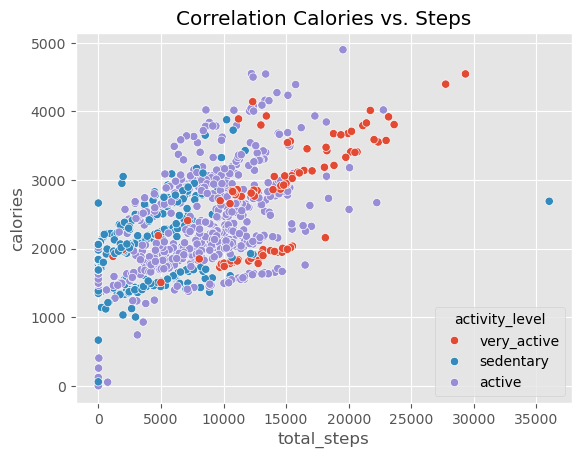

```python
ax =sns.scatterplot(x='total_steps', y='calories', data=df,hue='activity_level')

#handles, labels = ax.get_legend_handles_labels()
#plt.legend(handles, day_of_week, fontsize=7)
plt.title('Correlation Calories vs. Steps')

plt.show()
```

We can see in this scatterplot a **somewhat positive correlation** — the more steps taken, the more calories burned.  
The dots are color-coded based on the **activity_level** category, which helps us visualize which group each data point belongs to.

### Average Number of Steps per Day

Now, let's calculate the **average number of steps per day** across all users to get an overall idea of their daily activity levels.

[figure not shown]

```python
day_of_week = ['Monday','Tuesday','Wednesday','Thursday', 'Friday','Saturday','Sunday']
fig, ax =plt.subplots(1,1,figsize=(9,6))

day_grp = df.groupby(['day_of_week'])
avg_daily_steps= day_grp['total_steps'].mean()
avg_steps = df['total_steps'].mean()

plt.bar(avg_daily_steps.index,avg_daily_steps)

ax.set_xticks(range(len(day_of_week)))
ax.set_xticklabels(day_of_week)

ax.axhline(y=avg_daily_steps.mean(),color='red', label='Average daily steps')
ax.set_ylabel('Number of steps')
ax.set_xlabel('Day of the week')
ax.set_title('Avg Number of steps per day')

plt.legend()
plt.show()
```

### Percentage of Activity in Minutes

Next, let's calculate **what percentage of the day users spend being active** compared to the total minutes recorded (including sedentary time).

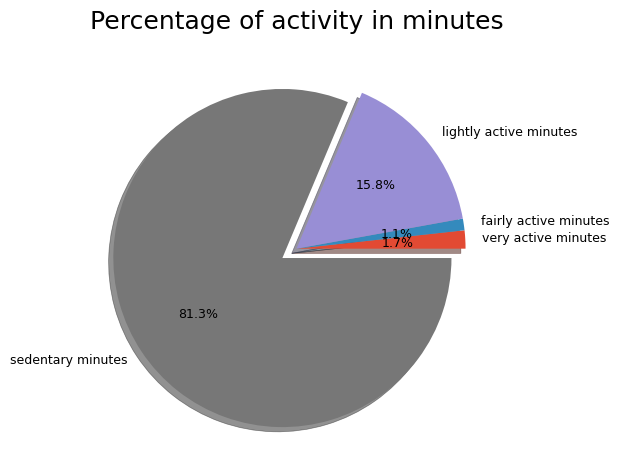

```python
very_active_mins = df['very_active_minutes'].sum()
fairly_active_mins = df['fairly_active_minutes'].sum()
lightly_active_mins = df['lightly_active_minutes'].sum()
sedentary_mins = df['sedentary_minutes'].sum()

slices = [very_active_mins,fairly_active_mins,lightly_active_mins,sedentary_mins]
labels = ['very active minutes','fairly active minutes','lightly active minutes','sedentary minutes']
explode = [0,0,0,0.1]
plt.pie(slices, labels = labels, explode = explode, autopct='%1.1f%%',textprops=dict(size=9), shadow=True)

plt.title('Percentage of activity in minutes',fontsize=18)
plt.tight_layout()

plt.show()
```

### Correlation Between Activity Level Minutes and Calories

Now, let's explore how different levels of activity (very active, fairly active, lightly active, and sedentary minutes) correlate with the number of calories burned.  
This will help us understand which type of activity has the strongest relationship with calorie expenditure.

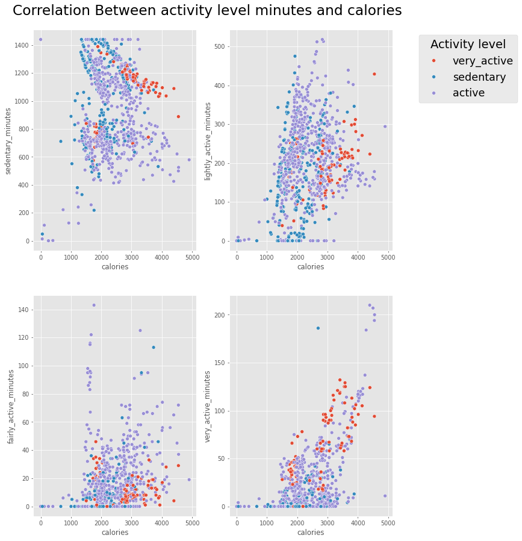

```python
n_day_of_week = [0,1,2,3,4,5,6]

fig, axes = plt.subplots(nrows=2, ncols=2,figsize=(11,15),dpi=70)

sns.scatterplot(data=df,x='calories',y='sedentary_minutes',hue='activity_level',ax=axes[0,0],legend=False)

sns.scatterplot(data=df,x='calories',y='lightly_active_minutes',hue='activity_level',ax=axes[0,1],legend=False)

sns.scatterplot(data=df,x='calories',y='fairly_active_minutes',hue='activity_level',ax=axes[1,0],legend=False)

sns.scatterplot(data=df,x='calories',y='very_active_minutes',hue='activity_level',ax=axes[1,1])


plt.legend(title='Activity level',title_fontsize=20,bbox_to_anchor=(1.8,2.2),fontsize=18,frameon=True,scatterpoints=1)
fig.suptitle('Correlation Between activity level minutes and calories',x=0.5,y=0.92,fontsize=24)
plt.show()
```

### Step 6: Act

After analyzing the **FitBit Fitness Tracker** data, we’ve identified several insights that could help shape **Bellabeat’s marketing strategy**.

### A Multipurpose Device

Bellabeat can reposition its products as **everyday wellness companions** that support users throughout their **entire day** — whether they’re working, commuting, or doing household chores.  
By emphasizing overall health tracking and lifestyle improvement, Bellabeat can attract women from diverse backgrounds who care about maintaining a balanced and healthy lifestyle.

### Rewards and Reminders

Bellabeat could integrate **motivational features** within the Bellabeat app or devices, such as **rewards, challenges, and reminders**, to encourage consistent healthy habits.

Some ideas include:

- Setting daily or weekly goals, like achieving **7,500 steps per day**, **burning a target number of calories**, or maintaining **8 hours of sleep**.
- Offering **virtual medals**, **badges**, or **discounts** for users who consistently meet these goals.
- Displaying a **leaderboard** to inspire friendly competition among users.
- Sending **personalized notifications** when users fall behind on their goals, along with helpful recommendations to improve their activity, sleep, or overall health.

These features would not only keep users engaged but also help build a sense of **motivation, accountability, and community** around Bellabeat’s products.